# Somerville Happiness Survey Report

Peter Madsen and Chris Salas

2020-12-07

# Introduction

### Research Question

1. How does a person’s age and annual income affect their opinion of the cost of housing?
2. How does a person’s gender affect how safe they feel walking at night?
3. How does a person’s age and annual income affect their trust in local police?

### Motivation

Problems within a community, such as prohibitive housing costs, declining sense of neighborhood safety, or increasing distrust in police, can be obvious and troubling to some groups of people and invisible to others. Additionally, as community problems increase in severity, they can affect some groups first, before spreading to others as the issues worsen. And since these problems are addressed by legislation (which is informed by public opinion), there is a danger that problems which could have been solved quickly and inexpensively at first will become extremely difficult or even impossible to solve by the time everyone is aware.

A pertinent analogy can be drawn from Environmental Science – an “indicator species” is a species which is especially sensitive to environmental contaminants and will show changes in behavior or a decline in population long before other species do, allowing it to serve as a warning sign, or “indicator,” of the health of the ecosystem as a whole. Knowing the indicator species for different environments allows for quick action against pollution events.

Similarly, if something like an “indicator demographic” can be identified for different community problems, this demographic can be used to detect and resolve issues early, before the social health of the entire community is damaged.

### Expectations

It is expected that homeowners, older people, and wealthier people will be more favorable of housing prices and be more trusting of local police.

Regarding the feeling that one’s neighborhood is safe to walk around at night, it is commonly known that men are more likely to feel safe than women and it is expected that this will be both visible and significant. Other demographic trends are hard to easily guess; within the survey used to explore these trends, the question asks about whether the respondent *feels* safe in their neighborhood at night but does not measure whether they actually *are* or not.

### Description of Variables

Explanatory variables:

- Gender - categorical
- Age - categorical (bins)
- Ethnicity - categorical
- Annual income - categorical (bins)
- Student - categorical (binary)
- Own/rent home? - categorical

Response variables:

- How do you rate the cost of housing? (quantitative)
- How safe do you feel walking at night? (quantitative)
- How would you rate your trust in the local police? (quantitative)

# Data Description

The city of Somerville lies just northwest of Boston and north of both Harvard University and the Massachusetts Institute of Technology. In 2011, 2013, 2015, and 2017, residents in Somerville were asked to fill out a survey which, among other topics, asked for respondents to rate their current feeling of happiness, their happiness with their life in general, and their satisfaction and pride about living in Somerville. This survey has since been called the “Somerville Happiness Survey,” but of interest in this project are the happiness-adjacent questions related to housing costs, feeling of safety, and trust in law enforcement. In 2017, there were twenty-seven questions in the survey and 835 responses.

Many respondents chose to leave questions blank, and care was taken to ensure entries were kept or removed with a reasonable logic. The presence of one or more blank fields can be seen as problematic, benign, or even meaningful depending on the context. For example, if a respondent left every demographic question blank, their opinion of housing costs problematically cannot be associated with an age, income, or gender, which is the goal of this project, but if only responses outside the scope of the project are left blank (e.g., “How anxious were you yesterday?”), these blanks are benign.

Entries were removed in the following order, resulting in a final sample size $n=631$:

1. After removing age-blank: 821 responses
2. After removing income-blank: 736 responses
3. After removing race/ethnicity-blank: 709 responses
4. After removing gender-blank: 703 responses
5. After removing low-n race/ethnicity: 662 responses
6. After removing house price zeros: 653 responses
7. After removing night safety zeros: 647 responses
8. After removing police trust zeros: 631 responses

Care was taken especially with respect to gender, for which the common model (that “male” and “female” are synonymous with “man” and “woman,” respectively, and together form mutually exclusive and collectively exhaustive subsets of humanity) is only a useful approximation with a small sample size. With hundreds of responses it is necessary to allow for the possibility that leaving the gender field blank, or answering both “male” and “female” simultaneously, is intended by a respondent to be a non-binary answer. While several responses were explicitly non-binary (e.g., “non-binary female” and “I don’t believe in the social construct of gender”), blank or both-male-and-female responses cannot exclusively be interpreted this way, as there are answers which explicitly describe multiple people (e.g. “multiple people live here,” “two people,” etc.). Therefore, gender responses were standardized into six categories: male, female, both, explicitly non-binary, explicitly multiple people, and blank. After age, income, and race/ethnicity blanks were removed, the total number of blank, both, non-binary, and multiple-people responses was 20, and ultimately these are unused in the project.

In this project, the Somerville Happiness Survey responses are analyzed for correlations tangential to happiness after having been filled out for another purpose. With no control groups or applied interventions — varying the explanatory variables here is either impossible or economically unfeasible — this is best understood as an observational study. The observational unit is one individual within a given household.

Questions on the survey can be considered as belonging to two types, categorical (e.g., “What is your gender?”) or quantitative (e.g., “How would you rate your trust in local police?”), with circled options or a rating scale, respectively. Quantitative questions varied the range and midpoint of the scale, rating from 1 to 10 for some questions and 1 to 5 for others.

# Descriptive Analysis

Analysis can be consider in two sections: first, concerning the trends that were expected to be present; second, trends which were unexpected but significant.

### General Demographics (Figure 1)

Before considering the views of individual subgroups, it is important to understand the broad demographics of Somerville represented in the survey responses.

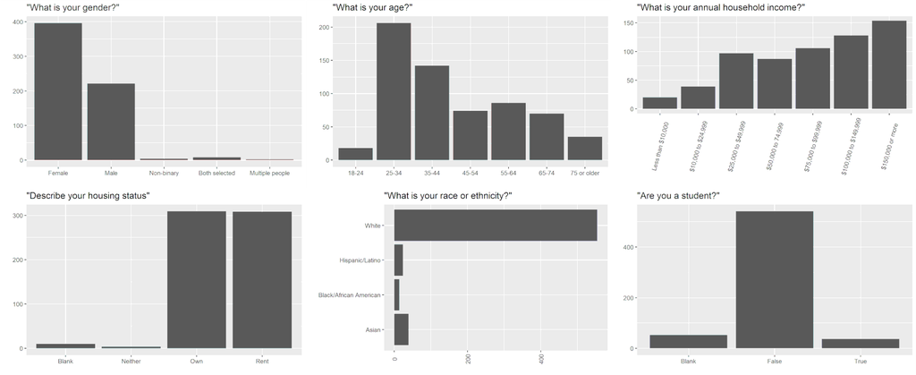

Fig. 1. An overview of Somerville demographics.

From the top left and moving clockwise, it is seen in Figure 1 that the majority of respondents by gender were female (proportion p=0.63), by age were between 25 to 34 years old (p=0.33), by income earned over $150,000 annually (p=0.24), were not students (p=0.86), by ethnicity were white (p=0.88), and were about equally likely to own a home as rent one (each p=0.49, from x=309 and x=308, respectively, and n=631). Because of the extreme disparity in race/ethnicity and student status responses, analysis was restricted to gender, age, annual income, and housing status.

### Concerning Expectations For Cost of Housing (Figures 2 to 4)

Because ratings comprised only 5 or 10 discrete values, the five number summaries for distributions of interest were often very similar or even identical. This can be seen in Figure 2, where the mean value is the only distinguishing feature between the two distributions. For this reason, the sample mean and sample standard deviation are considered as the parameters of interest.

As expected, those who own a home rate the cost of housing more favorably (2.42±1.18, mean±standard deviation) than those who rent (2.01±1.08), though both groups rate it poorly (Fig. 2; p<0.001). Unexpectedly, those who earned less than $10,000, between $10,000 to $24,999, and between $25,000 to $49,999 annually — the three poorest subgroups — rated the cost of housing most favorably (2.85±1.69, 2.44±1.37, and 2.29±1.28, respectively), and overall the mean rating *decreased* as income increased (Fig. 3).

Only 18 respondents were in the 18-24 age group, and they reported the highest favorability (Fig. 4; 2.89±1.02), followed by the 65-74 age group (2.73±1.46) and the 75 or older group (2.71±1.36). The expected trend, that increasing age correlates with approval of house prices, is evident from the 35-44 group up to the 65-74 group. Respondents between the age of 35 and 44 were the most disapproving (1.91±0.85).

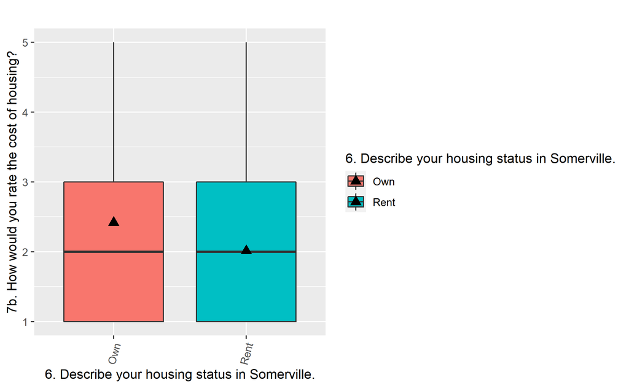

Fig. 2. Favorability of house prices by owners and renters of homes. Mean values superimposed as black triangles.

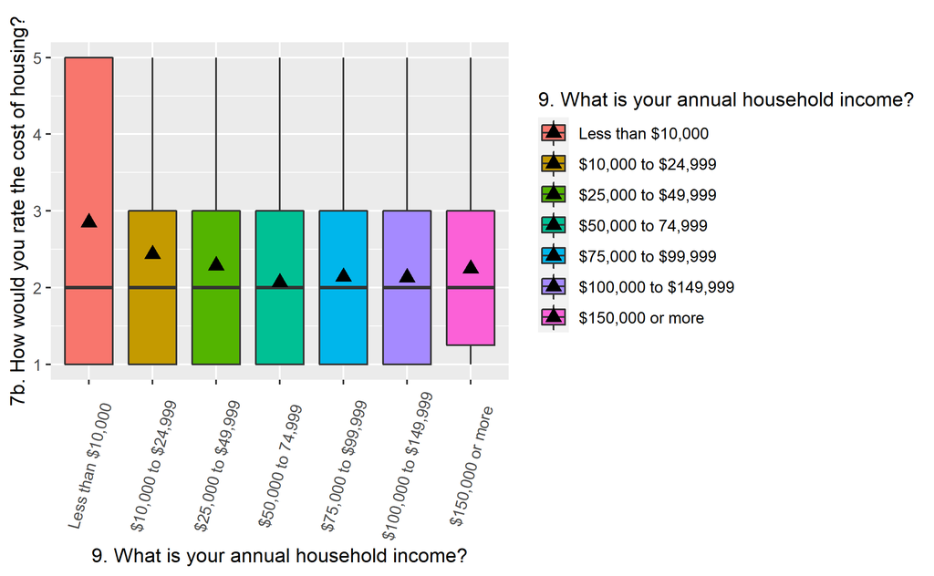

Fig. 3. Favorability of house prices by annual income.

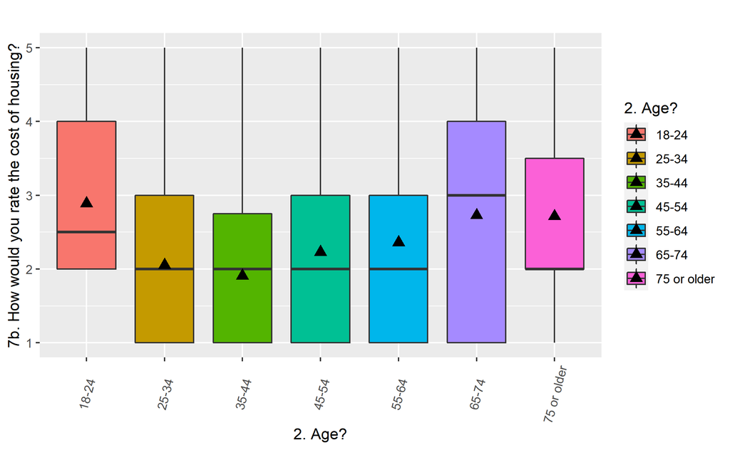

Fig. 4. Favorability of house prices by age group.

### Concerning Expectations For Feeling Safe At Night (Figure 5)

As expected, female respondents ranked their feeling of safety walking in their neighborhood at night lower than male respondents (Fig. 5; 7.87±2.03 for women, compared to 8.39±1.90 for men; p<0.001).

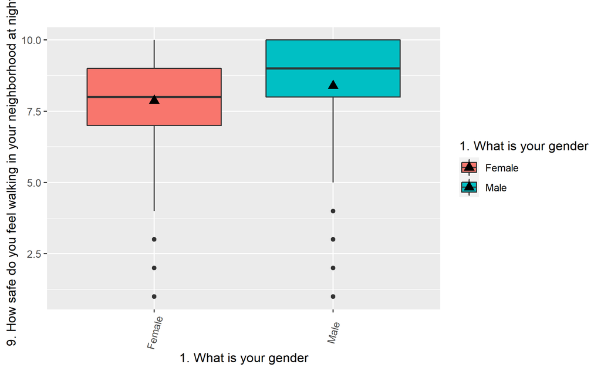

Fig. 5. Feeling of safety walking in neighborhood at night by gender.

### Concerning Expectations For Trust in Local Police (Figures 6 and 7)

Rather than increasing as expected, each annual income group has approximately the same mean rating for trust in local police (about 3.7 or 3.8), but the variation in the responses decreases as income increases, beginning at standard deviation 1.27 for those earning less than $10,000 and decreasing to 0.84 for those earning more than $150,000 (Fig. 6). As expected, respondents’ age correlates with trust in the local police (Fig. 7), beginning at 3.60±0.97 for 25-34 year olds and ending at 4.46±0.61 for respondents over 75.

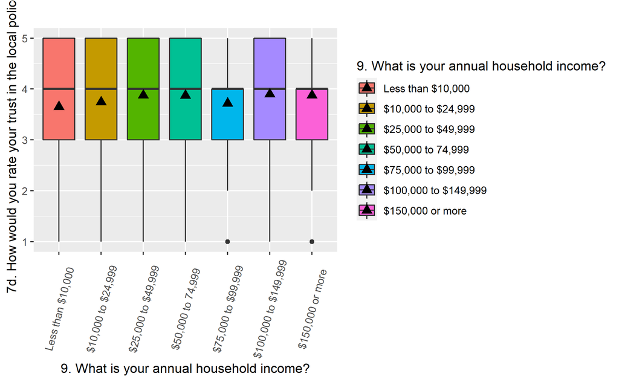

Fig. 6. Trust in local police by annual income.

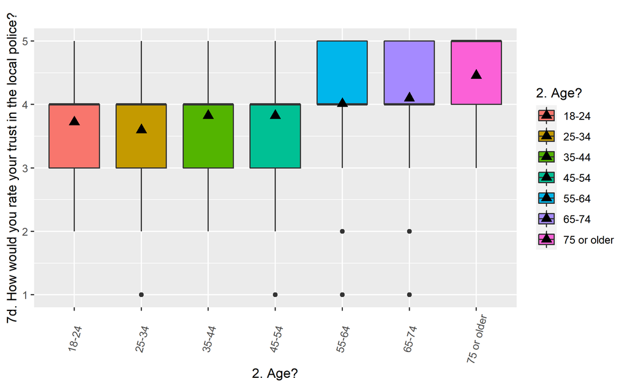

Fig. 7. Trust in local police by age.

### Renting vs. Owning a Home (Figures 8 to 11)

The original scope of the project focused primarily on age, gender, and annual income as explanatory variables, but whether or not a respondent owns the home they live in produces consistently dramatic differences in responses, possibly due to their differences in demographic composition. People who rent are overwhelmingly younger (Fig. 8) and poorer (Fig. 9) than their homeowning counterparts, and they report a lower life satisfaction (Fig. 10; 7.60±1.83, compared to 8.13±1.70 for owners; p<0.001), a lower trust in local police (Fig. 11; 3.73±0.95, compared to 3.94±0.96 for owners; p<0.005), and a lower favorability toward the cost of housing (Fig. 2; 2.01±1.08, compared to 2.42±1.18; p<0.001).

A question worth exploring in the future is whether these trends are simply due to the demographics of renters and homeowners, or whether a respondent’s homeowning status is more than the sum of their demographics and unique predictor of their views.

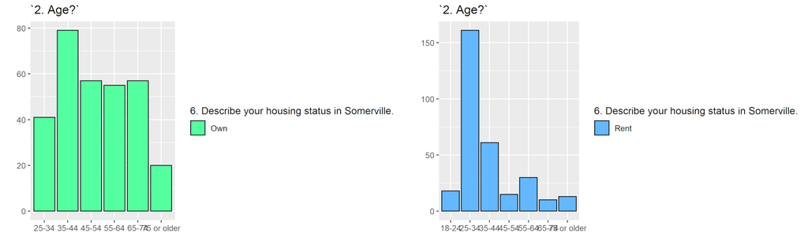

Fig. 8. Distribution of age groups for homeowners and renters.

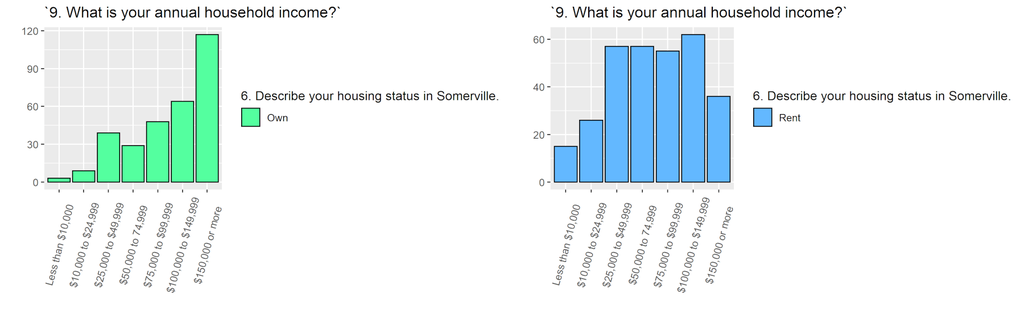

Fig. 9. Distribution of annual income for homeowners and renters.

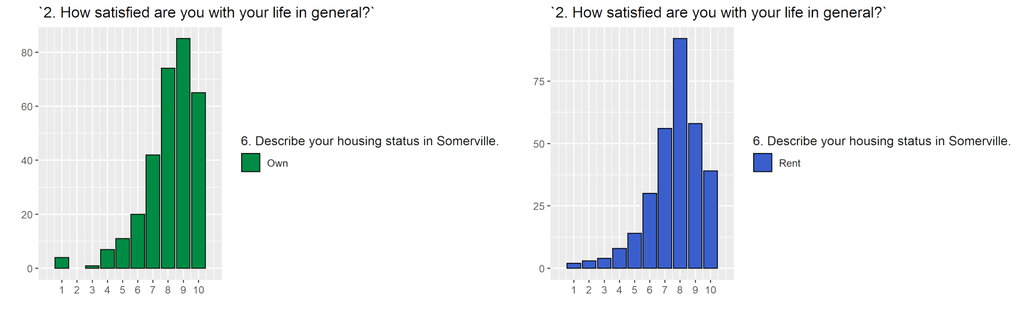

Fig. 10. General life satisfaction for homeowners and renters.

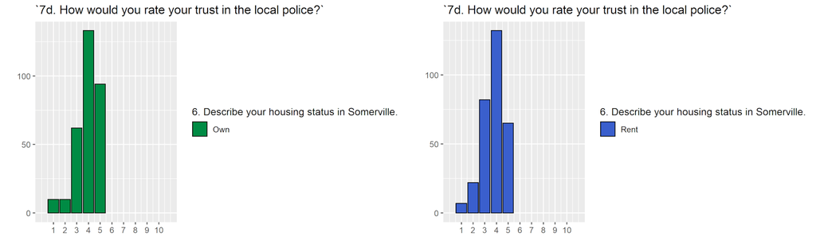

Fig. 11. Trust in police by homeowners and renters.

# Inferential Analysis

As an example, let us consider homeowners’ and renters’ responses to “How satisfied are you with your life in general?”, shown in Figure 10. Each of these has a sample size much greater than 40, so the normal test is sufficient. Here, the null hypothesis would be “while the mean life satisfaction for renters is lower than that for homeowners, this is due to randomness only” and the alternative hypothesis, which we aim to demonstrate, is “renters’ mean life satisfaction is lower than homeowners’ such that randomness alone is an unlikely explanation.”

In *R*, it was calculated thusly:

```r
library(tidyverse)
library(readr)

# The full survey data set with blanks removed
fullsomerville2017 <- read_csv("Supplemental/cleanedData/2017HappinessSurvey.csv")
fullsomerville2017 = fullsomerville2017 %>% filter(`2. Age?` != "Blank" &
                                                     `9. What is your annual household income?` != "Blank" &
                                                     `4. What is your race or ethnicity?` != "Blank" &
                                                     `1. What is your gender` != "Blank" &
                                                     `7b. How would you rate the cost of housing?` != 0 &
                                                     `9. How safe do you feel walking in your neighborhood at night?` != 0 &
                                                     `7d. How would you rate your trust in the local police?` != 0)
fullsomerville2017 = fullsomerville2017 %>% filter(`4. What is your race or ethnicity?` == "White" |
                                                     `4. What is your race or ethnicity?` == "Asian" |
                                                     `4. What is your race or ethnicity?` == "Hispanic/Latino" |
                                                     `4. What is your race or ethnicity?` == "Black/African American")


# Separating homeowners and renters into separate data frames
owners = fullsomerville2017 %>% filter(`6. Describe your housing status in Somerville.` == "Own")
renters = fullsomerville2017 %>% filter(`6. Describe your housing status in Somerville.` == "Rent")


# Defining the function to determine the p-value
determine_p_values_between_two_things = function(column, dataframe_H_0, dataframe_H_A) {
  y_bar = mean(pull(dataframe_H_0, column))
  x_bar = mean(pull(dataframe_H_A, column))
  y_sample_stdev_squared = sd(pull(dataframe_H_0, column))^2
  x_sample_stdev_squared = sd(pull(dataframe_H_A, column))^2
  m_sample = length(pull(dataframe_H_0, column))
  n_sample = length(pull(dataframe_H_A, column))
  sqrt_of_stdevs_and_ns = sqrt(x_sample_stdev_squared/m_sample + y_sample_stdev_squared/n_sample)
  Z = (x_bar - y_bar) / sqrt_of_stdevs_and_ns
  other_Z = (y_bar - x_bar) / sqrt_of_stdevs_and_ns
  if (Z <= 0) {
    print(paste("p-value:", pnorm(Z)))
  } else {
    print(paste("p-value:", pnorm(other_Z)))
  }
}


# printing out the p-value between homeowners' and renters' sense of happiness with life in general
print("Renters' mean life satisfaction is lower than homeowners' such that randomness alone is an unlikely explanation.")
```

```
## [1] "Renters' mean life satisfaction is lower than homeowners' such that randomness alone is an unlikely explanation."
```

```r
determine_p_values_between_two_things(column = 3, dataframe_H_0 = owners, dataframe_H_A = renters)
```

```
## [1] "p-value: 0.000122308034383805"
```

# Conclusion

It was expected that increasing annual income and age would each correlate with increasing favorability of the cost of housing and increasing trust in local police. This was not true with annual income (Figs. 3 and 6), but was true with age (when the 18-24 group is omitted; Figs. 4 and 7). Additionally, the common assumption that women feel less safe walking at night than men do is seen in the Somerville Happiness Survey, with p-value < 0.001 (Fig. 5).

These conclusions, however, cannot be generalized beyond the population of Somerville, as the densely populated, wealthy, urban environment is much different from the sparse, rural setting in other parts of the United States.

In the future, the differences in opinion and experience between renters and homeowners should be explored in more detail, as they differ dramatically (Figs. 8-11 and 2) and lend themselves well to p-value calculation.

```r
# End
```